# Assignment 4

John Busker & Sven Schoonen

24-5-2022

# Introduction

Corticosteroids are hormones produced by the adrenal cortex or synthetic analogues of these natural hormones. They are needed to release and store energy, minerals and salts. Theyre the most effective drugs’for anti-inflammatory and hypersensitivity reactions. Corticosteroids bind intracellularly to the corticosteroid receptor, forming a complex that influences the expression of mRNA. This induces the synthesis of certain proteins. Corticosteroids are mainly divided into two types:

- Mineralocorticoids *mainly affect the water and salt balance.*
- Glucocorticoids *have an effect on carbohydrate, protein and fat metabolism.*

The production (synthesis) mRNA is constant and the degradation of mRNA is a ratio that depends on the amount of mRNA. The amount of mRNA in time change depends on what is being made and broken down. mRNA affects the receptor, more mRNA means more synthesis of the receptor. The same applies to degradation. The speed of binding is equal to the amount of product of the activity. What is bound to the MPL concentration is thus withdrawn from the free receptor concentration. A part also goes to the nucleus and this depends on the amount that is available. There is also a factor because some of it goes back and becomes available and affects the amount of free receptor concentration. But the synthesis can still be influenced with a repression factor by the drug complex.

# Methods

The data from the experiment is compared with the simulation data to assess the model validity. The best way to do this is plotting the model results and the experimental results in one graph. The model results have one value per time unit, the experimental results have multiple values per time unit. The median results for each time unit has been calculated with the `aggregate` function.

The model has been created with the `ode` function of thye deSolve package.

# Results

[1]*Why is it best practice to plot the median for the experimental data?*

We can check if our model is any good by plotting the median of the experimental data.

[2]*How do the results of the simulations depend on the dose and concentration of the drug?*

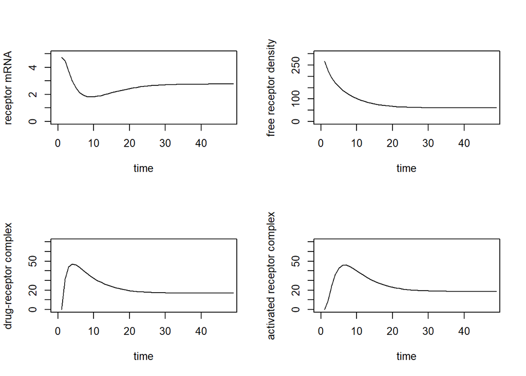

*Figure 1: The normal receptor model*

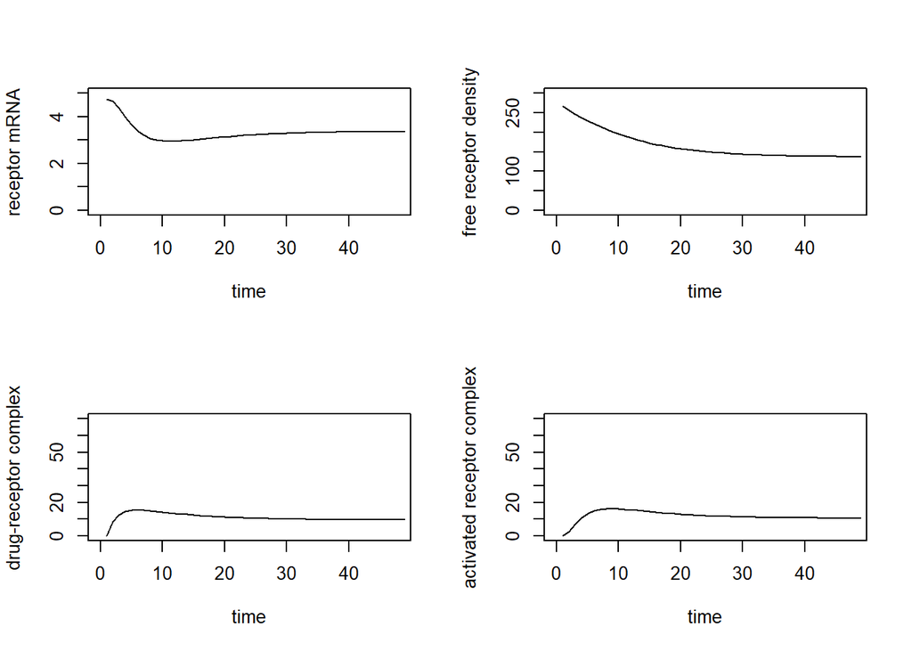

*Figure 2: The receptor model with a lower D value*

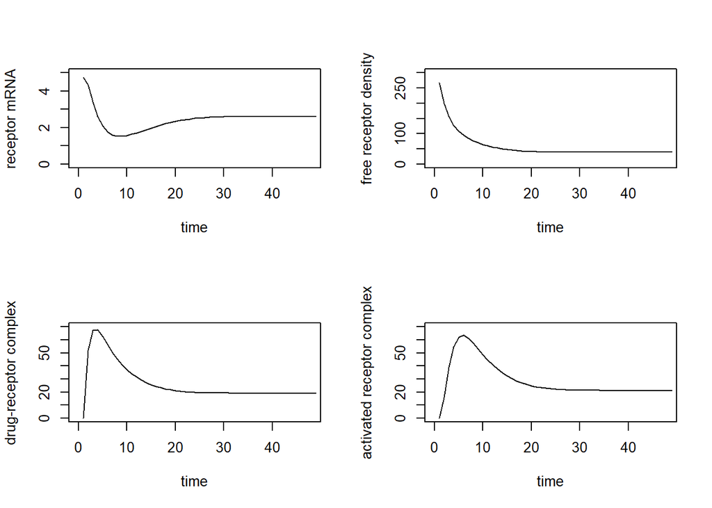

*Figure 3: The receptor model with a higher D value*

As you can see if you lower the D value, the amount of mRNA receptor and free receptor density gets higher dan with a value of 20. But drug-receptor complex and activated drug complex goes down. If you up tha value of D than the amount of mRNA receptor get slightly lower, the free receptor density is lower than before. Drug-receptor complex and activated drug complex have a higher peak than before and has a slightly higher equity.

[3]*Are the results of the model in line with experimental data? If not, what could be the reason?*

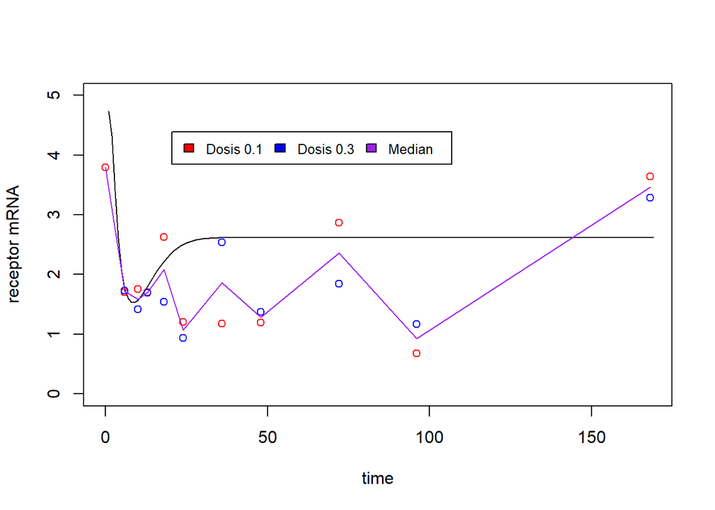

*Figure 4: Receptor mRNA model with the data of the experiment*

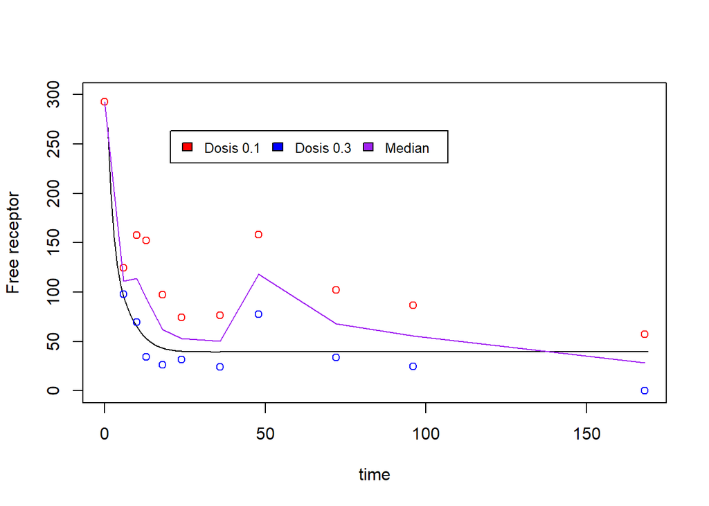

The free receptor model follows the data of the experiment. But the concentration of receptor mRNA doesn’t follow the experimental data. A reason that is possible is that the data is skewed. it is possible that the base level of free receptor oncentration is higher than we suspected. Or the base level or concentration receptor mRNA lower.

[1]*What would be the time course concentration of the activated drug-receptor complex if there was no auto-regulation of glucocorticoid receptor, i.e. if there was not effect of drug on the synthesis of the receptor mRNA?*

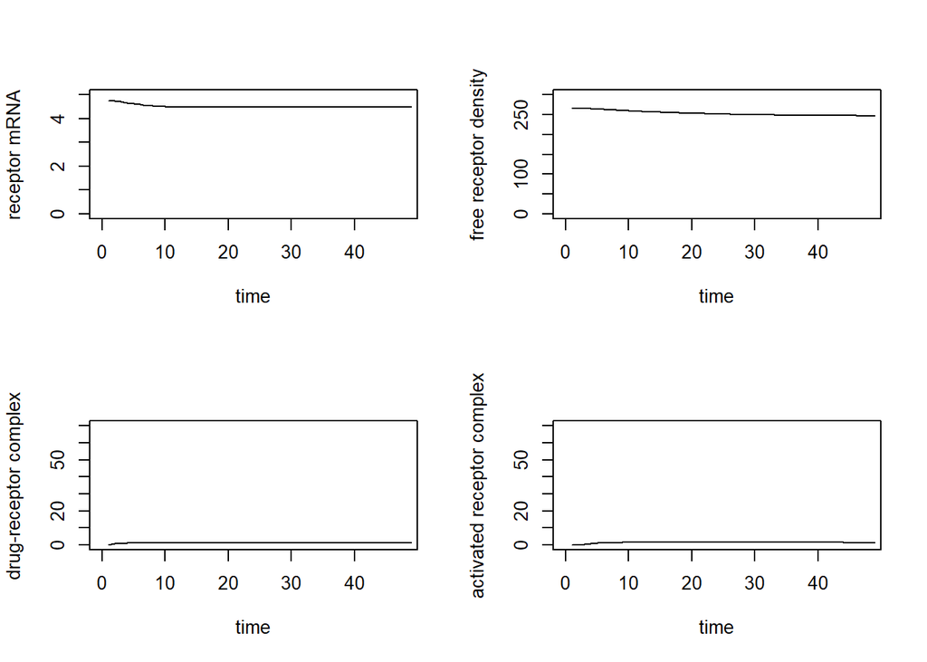

*Figure 6: The receptor model if there was no auto-regulation of glucocorticoid receptor*

Receptor mRNA and free receptor density barely goes down from the beginning state. And drug-receptor and activated receptor complex barely goes up from the beginning state.

[2]*What is the time course of receptor and mRNA concentrations when the drug treatment is stopped?*

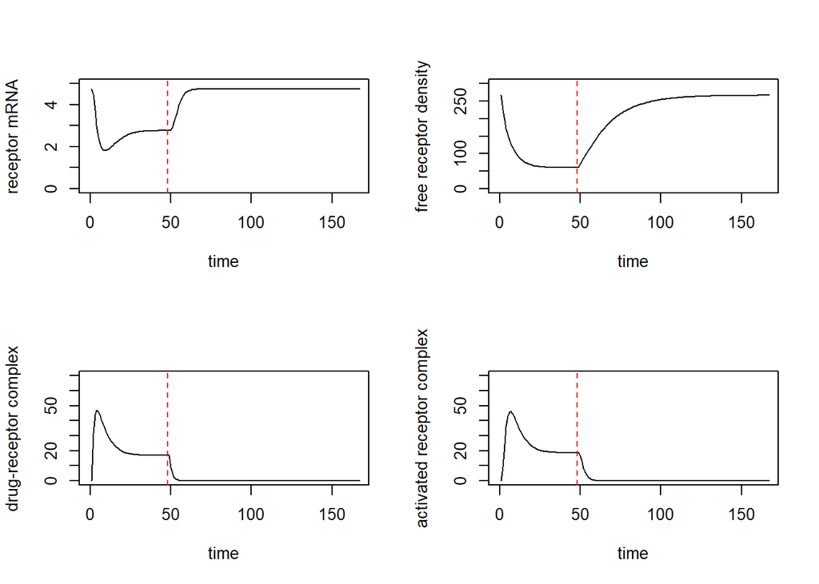

[3]*What is the effect of different values of kon and kre on the receptor and mRNA dynamics?*

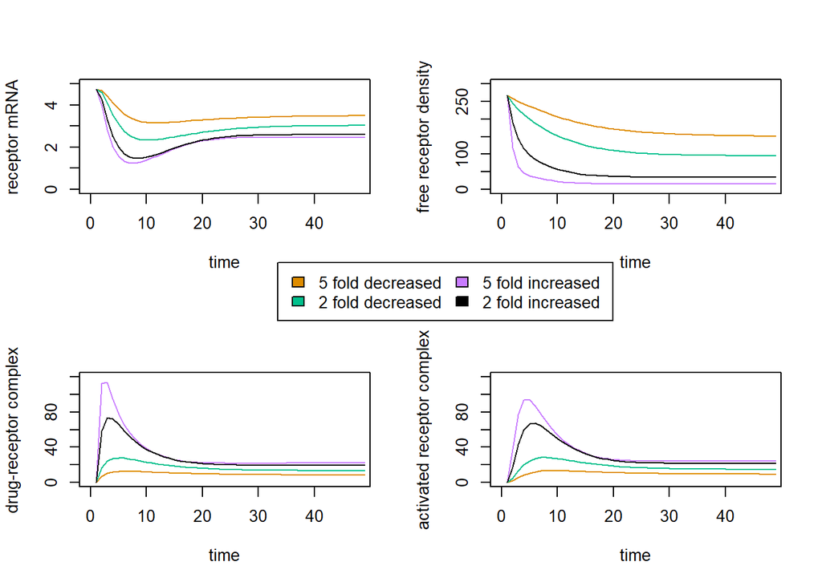

*Figure 8: The receptor model and the effect of a increased/decreased fold value change of Kon*

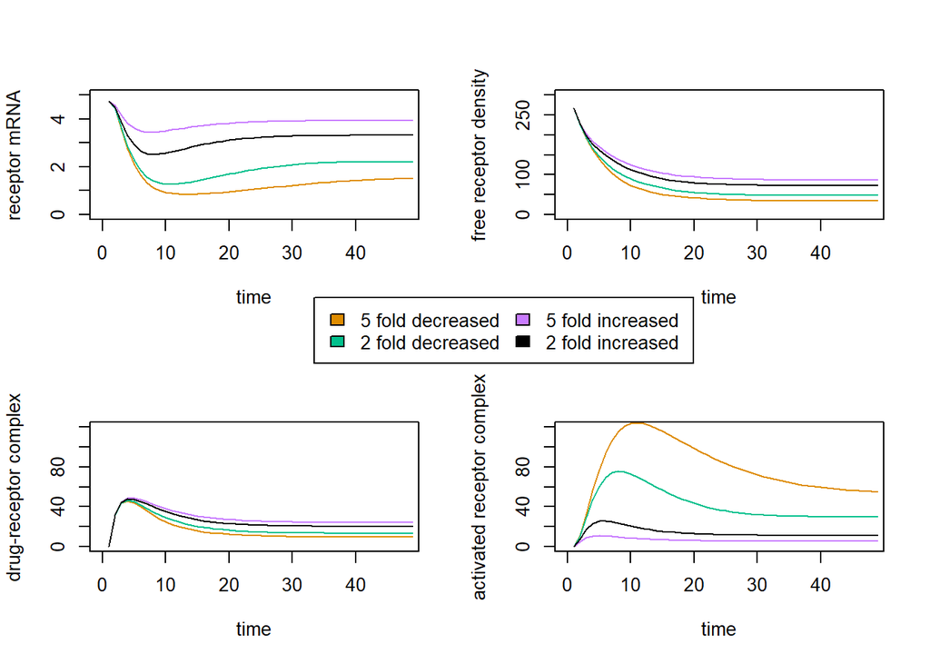

*Figure 9: The receptor model and the effect of a increased/decreased fold value change of Kre*

[4]*What would happen if the synthesis of the receptor was completely blocked?*

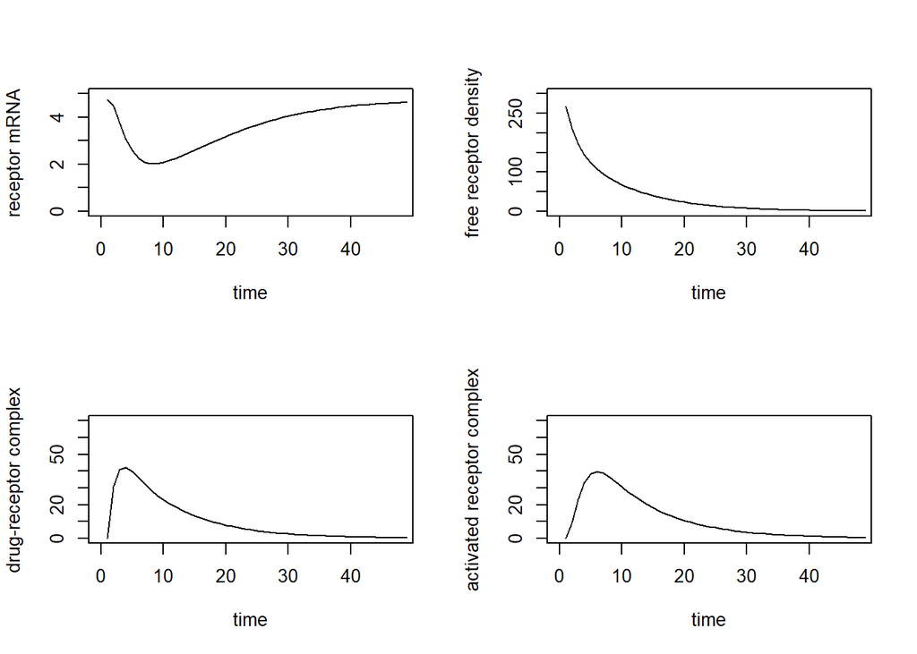

*Figure 10: The receptor model if the synthesis of the receptor was completely blocked*

[5]*What is the dynamic of the system when the baseline rate of production of mRNA of the receptor is increased or decreased 2 or 5 fold?*

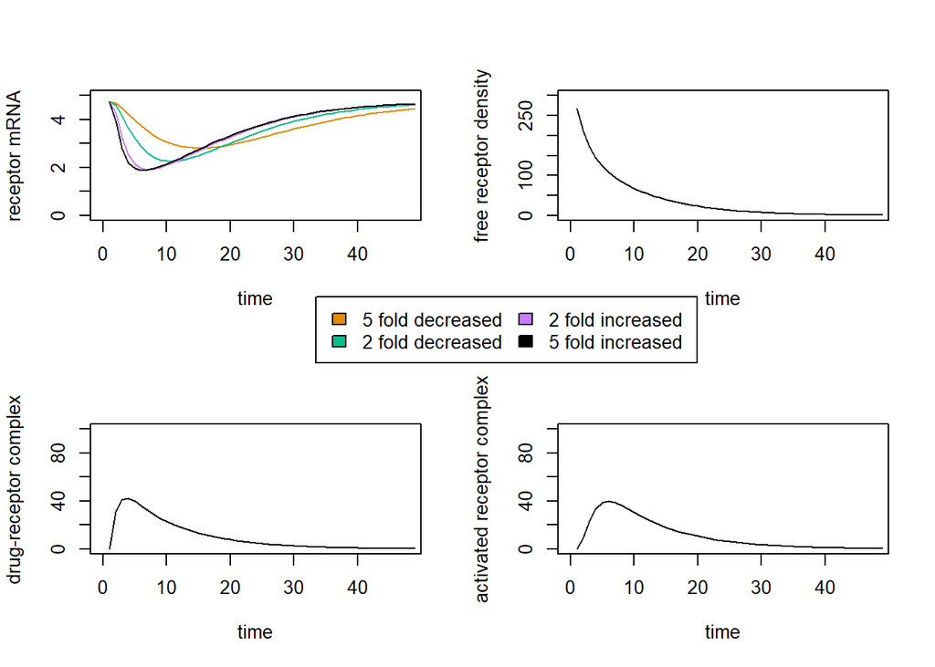

*Figure 11: The receptor model if the baseline rate of production of mRNA of the receptor is increased or decreased with a 2 or 5 fold change*

Almost nothing changed than before. Nothing significant changed than before the increased/decreased 2/5 fold change.

# Discussion

When K<sub>s_Rm</sub> and K<sub>d_Rm</sub> are increased/decreased with a2/5 fold change almost nothing change. If the D value is lower, the amount of mRNA receptor and free receptor density gets higher than with a value of 20. But drug-receptor complex and activated drug complex goes down. If the value of D is higher than 20, than the amount of mRNA receptor get slightly lower, the free receptor density is lower than before. Drug-receptor complex and activated drug complex have a higher peak than before and has a slightly higher equity.

The free receptor model follows the data of the experiment. But the concentration of receptor mRNA doesn’t really follow the experimental data. A reason that is possible is that the data is skewed. it is possible that the base level of free receptor concentration is higher than we suspected. Or the base level or concentration receptor mRNA lower.

With more data you can really compare the experimental data with the model.